# Developing Data Products Wk4 PJ - Shiny App

Ellie Kim

2018-05-24

## Project Objectives :

- To create a Shiny Application :
1. Create a shiny application with associated supporting documentation
2. Need to include some widgets, operations on the ui.R and server.R
3. Some reactive output displayed as a result of server calculations
4. Deploy the application on Rstudio’s shiny server
- To create a R Presentation :
1. 5 slides to pitch the idea done in Slidify or Rstudio Presenter
2. Need to be pushed to github or Rpubs
3. Need to contain some embedded R code that gets run when slidifying the document

## The Shiny Application includes

Left Pane  
- textInput :Input your name  
- selectInput : Select swiss column X for modeling and plot  
- selectInput : Select swiss column Y for modeling and plot  
- checkboxInput : Tick checkboxs for X axis ,Y axis, and main title label  
- radiobuttons : Select radiobutton for plot image file download

Main Pane  
Four tabs in main panel as below :  
- Data : Displays swiss data observations  
- Summary : Displays summary for the swiss data  
- Modeling : Displays linear modeling for the data as per user selection  
- Plot : Displays plot, regression line and loess line for corresponding data

## Slide with R Output

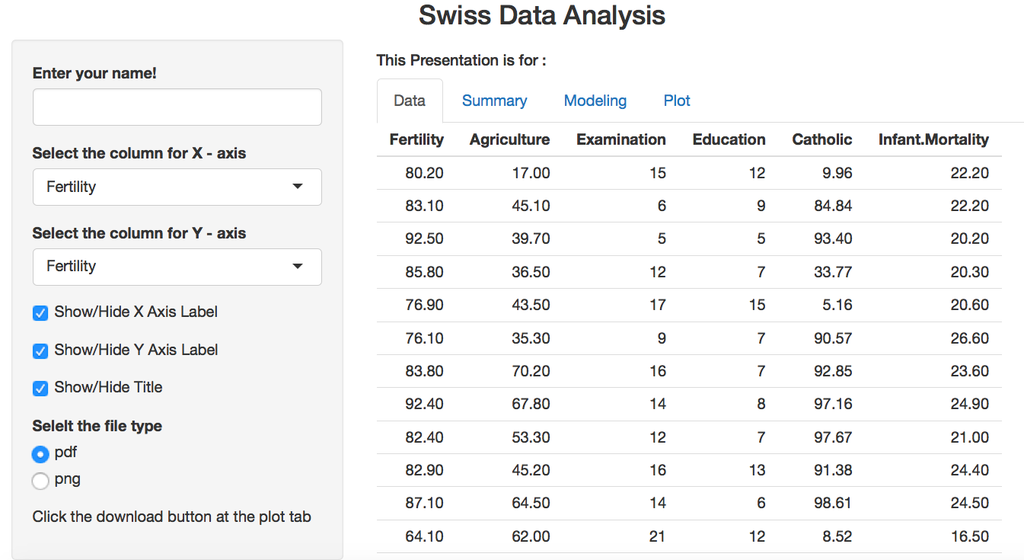

## Slide with Plot

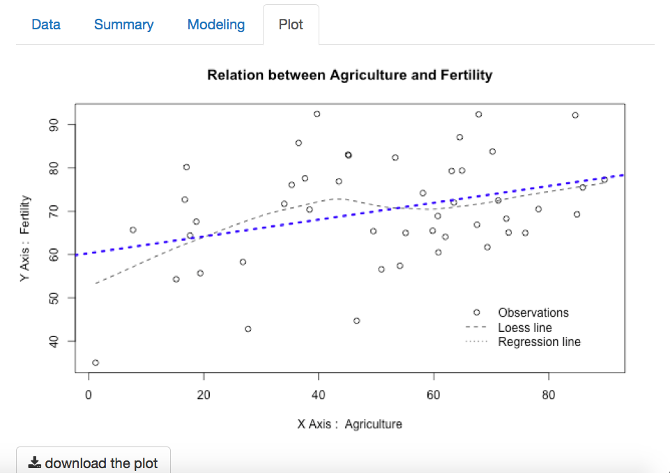

The Shiny App is avaialbe at shinyapps.io https://efractals.shinyapps.io/Wk4Project/  
The files are available at Github repository https://github.com/keunmee/DevelopingDataProjects

Thank you for reviewing!